# Covid_19_Project: Continued Analysis

Andrew Irani

9/22/2020

A pneumonia of unknown cause detected in Wuhan, China was first internationally reported from China on 31 December 2019. Today we know this virus as Coronavirus. COVID-19 which stands for COronaVIrus Disease is the disease caused by this virus. Since then, the world has been engaged in the fight against this pandemic. Several measures have therefore been taken to “flatten the curve”. We have consequently experienced social distancing and many people have passed away as well.

In the solidarity to face this unprecedented global crisis, several organizations did not hesitate to share several datasets allowing the conduction of several kinds of analysis in order to understand this pandemic.

It is natural for us to analyze these datasets by ourselves to answer questions since we cannot always rely on the news, and we are data scientists.

This analysis tries to provide an answer to this question: **Which countries have had the highest number of positive cases against the number of tests?**

# Step 1: Understanding the data

```r
#install.packages('tidyverse')
library(tidyverse)
# Load the COVID dataset
covid_df <- read.csv("covid19.csv")
```

```r
# Data dimensions
library(tibble)
dim(covid_df)
```

```
## [1] 10903    14
```

```r
glimpse(covid_df)
```

```
## Rows: 10,903
## Columns: 14
## $ Date                    <fct> 2020-01-20, 2020-01-22, 2020-01-22, 2020-01-2…
## $ Continent_Name          <fct> Asia, North America, North America, North Ame…
## $ Two_Letter_Country_Code <fct> KR, US, US, US, US, KR, US, US, AU, AU, AU, A…
## $ Country_Region          <fct> South Korea, United States, United States, Un…
## $ Province_State          <fct> All States, All States, Washington, All State…
## $ positive                <int> 1, 1, 1, 1, 1, 2, 1, 1, 4, 0, 3, 0, 0, 0, 0, …
## $ hospitalized            <int> 0, 0, 0, 0, 0, 0, 0, 0, 0, 0, 0, 0, 0, 0, 0, …
## $ recovered               <int> 0, 0, 0, 0, 0, 0, 0, 0, 0, 0, 0, 0, 0, 0, 0, …
## $ death                   <int> 0, 0, 0, 0, 0, 0, 0, 0, 0, 0, 0, 0, 0, 0, 0, …
## $ total_tested            <int> 4, 1, 1, 1, 1, 27, 1, 1, 0, 0, 0, 0, 0, 0, 0,…
## $ active                  <int> 0, 0, 0, 0, 0, 0, 0, 0, 0, 0, 0, 0, 0, 0, 0, …
## $ hospitalizedCurr        <int> 0, 0, 0, 0, 0, 0, 0, 0, 0, 0, 0, 0, 0, 0, 0, …
## $ daily_tested            <int> 0, 0, 0, 0, 0, 5, 0, 0, 0, 0, 0, 0, 0, 0, 0, …
## $ daily_positive          <int> 0, 0, 0, 0, 0, 0, 0, 0, 0, 0, 0, 0, 0, 0, 0, …
```

```r
# Display variables
vector_cols <- colnames(covid_df)
vector_cols
```

```
##  [1] "Date"                    "Continent_Name"
##  [3] "Two_Letter_Country_Code" "Country_Region"
##  [5] "Province_State"          "positive"
##  [7] "hospitalized"            "recovered"
##  [9] "death"                   "total_tested"
## [11] "active"                  "hospitalizedCurr"
## [13] "daily_tested"            "daily_positive"
```

```r
# Quick overview of the data
head(covid_df)
```

```
##         Date Continent_Name Two_Letter_Country_Code Country_Region
## 1 2020-01-20           Asia                      KR    South Korea
## 2 2020-01-22  North America                      US  United States
## 3 2020-01-22  North America                      US  United States
## 4 2020-01-23  North America                      US  United States
## 5 2020-01-23  North America                      US  United States
## 6 2020-01-24           Asia                      KR    South Korea
##   Province_State positive hospitalized recovered death total_tested active
## 1     All States        1            0         0     0            4      0
## 2     All States        1            0         0     0            1      0
## 3     Washington        1            0         0     0            1      0
## 4     All States        1            0         0     0            1      0
## 5     Washington        1            0         0     0            1      0
## 6     All States        2            0         0     0           27      0
##   hospitalizedCurr daily_tested daily_positive
## 1                0            0              0
## 2                0            0              0
## 3                0            0              0
## 4                0            0              0
## 5                0            0              0
## 6                0            5              0
```

```r
glimpse(covid_df)
```

```
## Rows: 10,903
## Columns: 14
## $ Date                    <fct> 2020-01-20, 2020-01-22, 2020-01-22, 2020-01-2…
## $ Continent_Name          <fct> Asia, North America, North America, North Ame…
## $ Two_Letter_Country_Code <fct> KR, US, US, US, US, KR, US, US, AU, AU, AU, A…
## $ Country_Region          <fct> South Korea, United States, United States, Un…
## $ Province_State          <fct> All States, All States, Washington, All State…
## $ positive                <int> 1, 1, 1, 1, 1, 2, 1, 1, 4, 0, 3, 0, 0, 0, 0, …
## $ hospitalized            <int> 0, 0, 0, 0, 0, 0, 0, 0, 0, 0, 0, 0, 0, 0, 0, …
## $ recovered               <int> 0, 0, 0, 0, 0, 0, 0, 0, 0, 0, 0, 0, 0, 0, 0, …
## $ death                   <int> 0, 0, 0, 0, 0, 0, 0, 0, 0, 0, 0, 0, 0, 0, 0, …
## $ total_tested            <int> 4, 1, 1, 1, 1, 27, 1, 1, 0, 0, 0, 0, 0, 0, 0,…
## $ active                  <int> 0, 0, 0, 0, 0, 0, 0, 0, 0, 0, 0, 0, 0, 0, 0, …
## $ hospitalizedCurr        <int> 0, 0, 0, 0, 0, 0, 0, 0, 0, 0, 0, 0, 0, 0, 0, …
## $ daily_tested            <int> 0, 0, 0, 0, 0, 5, 0, 0, 0, 0, 0, 0, 0, 0, 0, …
## $ daily_positive          <int> 0, 0, 0, 0, 0, 0, 0, 0, 0, 0, 0, 0, 0, 0, 0, …
```

# Step 2: Cleaning up data

```r
# Extract only country level data
covid_df_all_states <- covid_df %>%
  filter(Province_State == "All States") %>%
         select(-Province_State)

# After filtering for "All states" the Province_State column is no longer needed because that's all it contains
```

```r
# Select the columns that are daily
covid_df_all_states_daily <- covid_df_all_states %>%
  select(Date, Country_Region, active, hospitalizedCurr, daily_tested, daily_positive)

# Select the columns that are related to cumulative measures
covid_df_all_states_cumulative <- covid_df_all_states %>%
  select(Date, Continent_Name, Two_Letter_Country_Code, positive, hospitalized, recovered, death, total_tested)
```

# Step 3: Question - Which countries have had the highest number of deaths due to COVID-19

```r
# Summarize the dataset
covid_df_all_states_cumulative_max <- covid_df_all_states_cumulative %>%
  group_by(Continent_Name, Two_Letter_Country_Code) %>%
summarise(death_max = max(death)) %>%
  filter(death_max > 0) %>%
  arrange(-death_max)

# Display the dataset
covid_df_all_states_cumulative_max
```

```
## # A tibble: 24 x 3
## # Groups:   Continent_Name [4]
##    Continent_Name Two_Letter_Country_Code death_max
##    <fct>          <fct>                       <int>
##  1 North America  US                          98536
##  2 Europe         IT                          33415
##  3 Europe         GB                          33186
##  4 Europe         BE                           8903
##  5 Asia           RU                           4693
##  6 Asia           TR                           4540
##  7 Europe         SE                           4395
##  8 North America  CA                           3682
##  9 Oceania        NZ                           1421
## 10 Europe         PL                           1065
## # … with 14 more rows
```

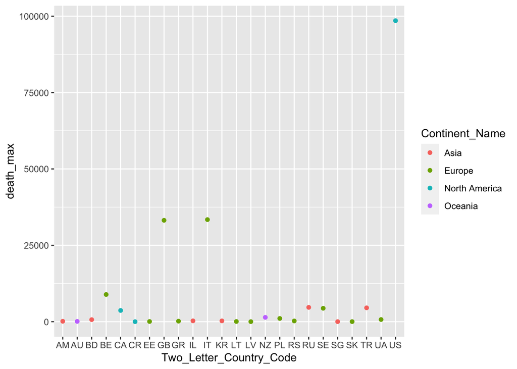

```r
# Visualize the maximum number of deaths for each country
death_top_3 <-  qplot(x = Two_Letter_Country_Code,
                      y = death_max,
                      color = Continent_Name,
                      data = covid_df_all_states_cumulative_max)
death_top_3
```

```r
# This graph works but is quite cluttered on the x axis
```

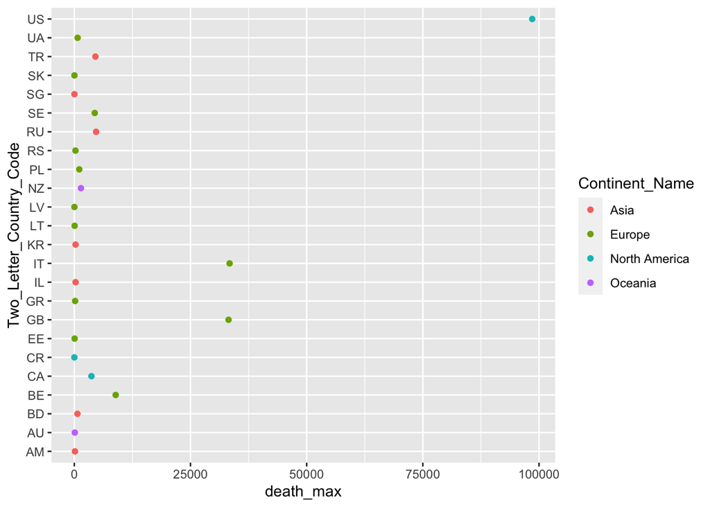

```r
# Create a graph that is easier to interpret
death_top_3 <-  qplot(x = death_max,
                      y = Two_Letter_Country_Code,
                      color = Continent_Name,
                      data = covid_df_all_states_cumulative_max)
death_top_3
```

```r
# Just buy switching the x and y it makes the entire graph more useful
```

```r
# Store the top 3 countris
death_top_3 <- c("US", "Italy", "GB")
```

# Step 4: Summarize the data

```r
# For each country get the total number of tested, positive, active, and hosipitalized
covid_df_all_states_daily_sum <- covid_df_all_states_daily %>%
  group_by(Country_Region) %>%
  summarise(tested_sum = sum(daily_tested),
            positive_sum = sum(daily_positive),
            active_sum = sum(active),
            hospitalized_sum = sum(hospitalizedCurr)) %>%
              arrange(-tested_sum)
head(covid_df_all_states_daily_sum)
```

```
## # A tibble: 6 x 5
##   Country_Region tested_sum positive_sum active_sum hospitalized_sum
##   <fct>               <int>        <int>      <int>            <int>
## 1 United States    17282363      1877179          0                0
## 2 Russia           10542266       406368    6924890                0
## 3 Italy             4091291       251710    6202214          1699003
## 4 India             3692851        60959          0                0
## 5 Turkey            2031192       163941    2980960                0
## 6 Canada            1654779        90873      56454                0
```

```r
# Store the top 10 countries
covid_top_10 <- head(covid_df_all_states_daily_sum, 10)
```

# Step 5: Question = Which countries have had the highest number of postive cases against the number of tests

```r
# Answer the question using vectors
countries <- covid_top_10$Country_Region
tested_cases <- covid_top_10$tested_sum
positive_cases <- covid_top_10$positive_sum
active_cases <- covid_top_10$active_sum
hospitalized_cases <- covid_top_10$hospitalized_sum
```

```r
# Naming vectors
names(positive_cases) <- countries
names(tested_cases) <- countries
names(active_cases) <- countries
names(hospitalized_cases) <- countries
```

```r
# Identify the top 3 countries
positive_tested_division <- positive_cases/tested_cases
positive_tested_division_sorted <- sort(positive_tested_division, decreasing = TRUE)
positive_tested_division_sorted
```

```
## United Kingdom  United States         Turkey          Italy           Peru
##    0.113260617    0.108618191    0.080711720    0.061523368    0.060910738
##         Canada         Russia         Poland          India      Australia
##    0.054915490    0.038546552    0.025840932    0.016507300    0.005746668
```

```r
# Display the top 3 countries
positive_tested_top_3 <- c("United Kingdom" = 0.11, "United States" = 0.10, "Turkey" = 0.08)
```

# Step 6: Complete the previous step using Tidyverse Dplyr

```r
# Same answer can be created using more robust code
positive_tested_top_3_tidy <- covid_top_10 %>%
  group_by(Country_Region) %>%
  mutate(positive_vs_tested = positive_sum/tested_sum) %>%
  arrange(-positive_vs_tested) %>%
  select(positive_vs_tested, Country_Region) %>%
  head(3)
positive_tested_top_3_tidy
```

```
## # A tibble: 3 x 2
## # Groups:   Country_Region [3]
##   positive_vs_tested Country_Region
##                <dbl> <fct>
## 1             0.113  United Kingdom
## 2             0.109  United States
## 3             0.0807 Turkey
```

# Step 7: Quantify the relationship between the number of cases and the population of each country

```r
# Create a matrix using the previous vectors
covid_mat <- cbind(tested_cases, positive_cases, active_cases, hospitalized_cases)

# Create a population vector
population <- c(331002651, 145934462, 60461826, 1380004385, 84339067, 37742154, 67886011, 25499884, 32971854, 37846611)

# complete the matrix
covid_mat <- covid_mat * 100/population

# Display the matrix
covid_mat
```

```
##                tested_cases positive_cases active_cases hospitalized_cases
## United States      5.221216    0.567119023    0.0000000         0.00000000
## Russia             7.223973    0.278459244    4.7452054         0.00000000
## Italy              6.766734    0.416312269   10.2580660         2.81004249
## India              0.267597    0.004417305    0.0000000         0.00000000
## Turkey             2.408364    0.194383227    3.5344949         0.00000000
## Canada             4.384432    0.240773221    0.1495781         0.00000000
## United Kingdom     2.170804    0.245866560    0.0000000         0.00000000
## Australia          4.913356    0.028235423    0.5277906         0.02609816
## Peru               2.962496    0.180447845    0.0000000         0.00000000
## Poland             2.452679    0.063379519    1.4220639         0.00000000
```

```r
covid_mat_tested_cases <- covid_mat[, "tested_cases"]

covid_mat_tested_cases
```

```
##  United States         Russia          Italy          India         Turkey
##       5.221216       7.223973       6.766734       0.267597       2.408364
##         Canada United Kingdom      Australia           Peru         Poland
##       4.384432       2.170804       4.913356       2.962496       2.452679
```